# Homework 3

Name: Antoine Marthey

UNI: am4665

```r
# library(vcdExtra)
# library(RColorBrewer)
# library(bayesm)
library(dplyr)
library(tidyr)
library(ggplot2)
library(vcd)
library(viridis)
library(ggmosaic)
# library(pgmm)
```

# Exercice 1

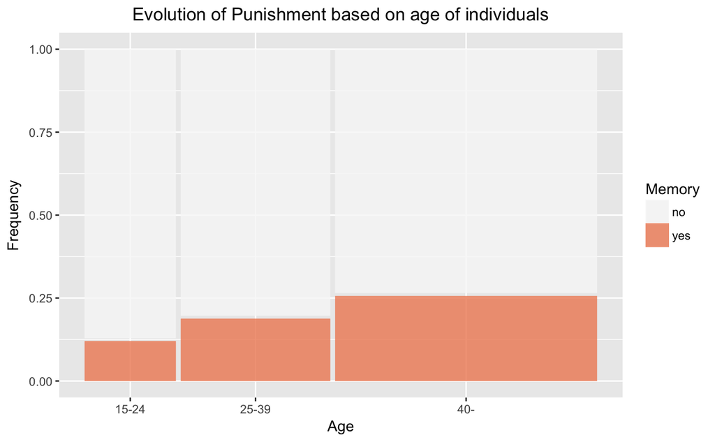

```r
data('Punishment')
ggplot(Punishment,aes(weight = Punishment$Freq, x = product(Punishment$age), fill=Punishment$memory)) +
  geom_mosaic() +
  scale_fill_brewer(palette = "RdBu") +
  xlab("Age") +
  ylab("Frequency") +
  labs(fill="Memory") +
  ggtitle("Evolution of Punishment based on age of individuals") +
  theme(plot.title = element_text(hjust = 0.5)) +
  guides(fill = guide_legend(reverse=TRUE))
```

Here is a plot for a single factor pattern. One can see that older individuals remember getting punished more. Nowadays, punishment is less present.

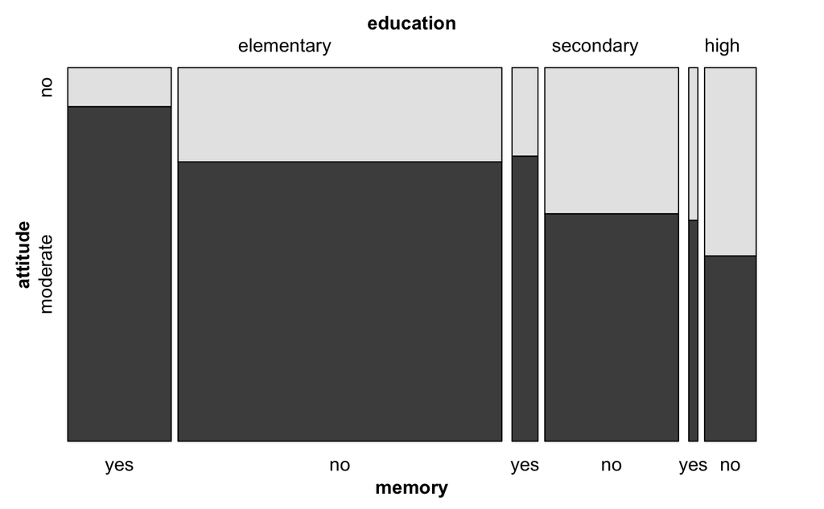

```r
mosaic(attitude ~ education + memory, data=Punishment, direction=c('v', 'v', 'h'))
```

Here is the conditioning of 3 variables together. One can see that the major factor that will condition punishment is the memory factor. If one was punished in the past then his attitude will be more moderated.

# Exercice 2

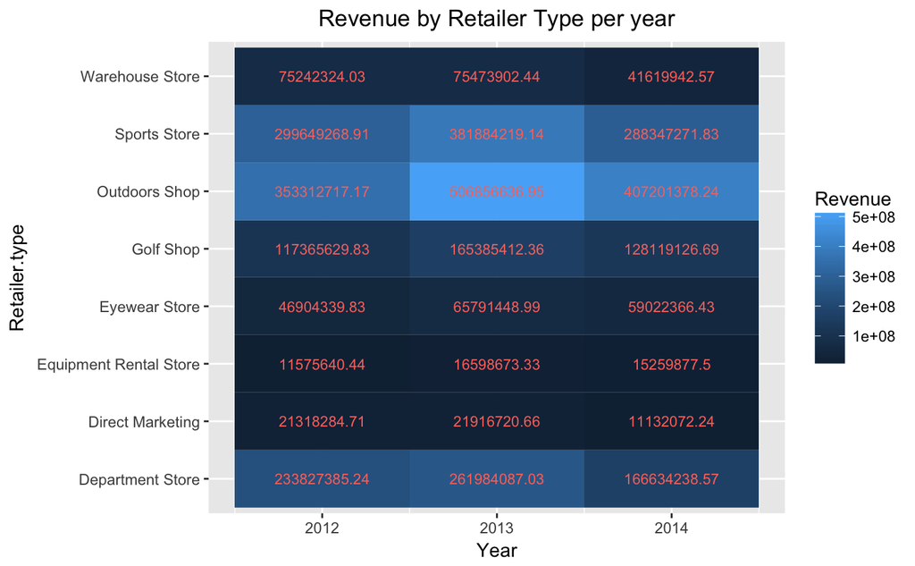

```r
Sales <- read.csv("WA_Sales_Products_2012-14.csv", header = TRUE, sep = ",")
Sales_per_year <- Sales %>% group_by(Retailer.type,Year) %>% summarise(Revenue=sum(Revenue))
ggplot(Sales_per_year, aes(Year, Retailer.type,fill = Revenue)) +
  geom_tile() +
  geom_text(aes(label = Revenue, colour = "red"),size = 3) +
  ggtitle("Revenue by Retailer Type per year") +
  theme(plot.title = element_text(hjust = 0.5)) +
  guides(color = FALSE)
```

First we group by Retailer.type and Year in order to analyze the evolution of each type throughout the years (2012,2013,2014). Then we summarise by adding all the revenue for this two attributes.

From this heatmap, we can directly derive that 2013 was a great year for our business, and that Outdoors Shop, Sports Store and Department Store are our 3 main sources of income.

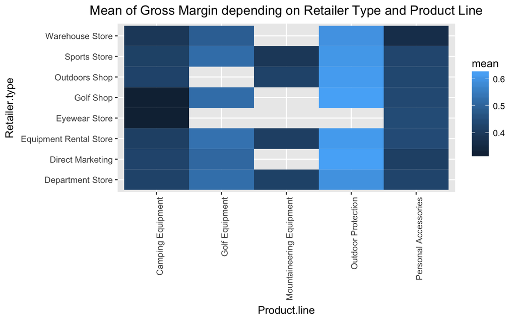

```r
Sales_gross_margin <- na.omit(Sales)
Sales_gross_margin <- Sales_gross_margin %>% group_by(Retailer.type, Product.line) %>% summarise(mean=mean(Gross.margin))
Sales_gross_margin <- na.omit(Sales_gross_margin)
ggplot(data=Sales_gross_margin, aes(x=Product.line, y=Retailer.type)) +
 geom_tile(aes(fill=mean)) +
 theme(axis.text.x=element_text(angle = 90, hjust = 1), plot.title=element_text(hjust = 0.5)) +
 ggtitle("Mean of Gross Margin depending on Retailer Type and Product Line")
```

From the heatmap above, one can tell that Outdoors Equipement is representing a line of product where we make a maximum Gross Margin Profit when we sell it with Direct Marketing. At the opposite selling Camping equipment in a Golf Shop won’t provide a huge Grosse Margin.

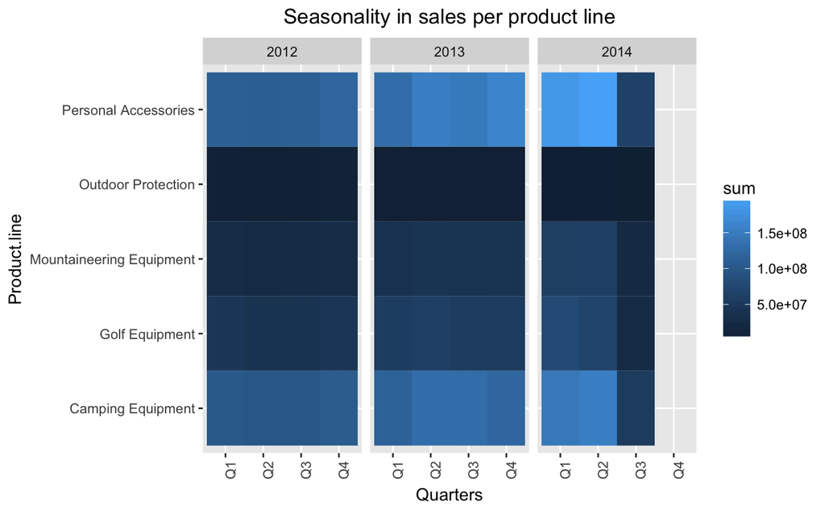

```r
Sales_quarter <- Sales %>% separate(Quarter, c("Quarters", "Y_Q")) %>% group_by(Product.line,Quarters,Year) %>% summarise(sum=sum(Revenue))
ggplot(data=Sales_quarter, aes(x=Quarters, y=Product.line)) +
 geom_tile(aes(fill=sum)) +
 facet_wrap(~Year) +
 theme(axis.text.x=element_text(angle = 90, hjust = 1), plot.title=element_text(hjust = 0.5)) +
 ggtitle("Seasonality in sales per product line")
```

From this heatmap, one can see that there is no clear seasonality of sales during 2012, 2013, 2014. The planning and forecast should not be based on seasonality.

# Exercice 3

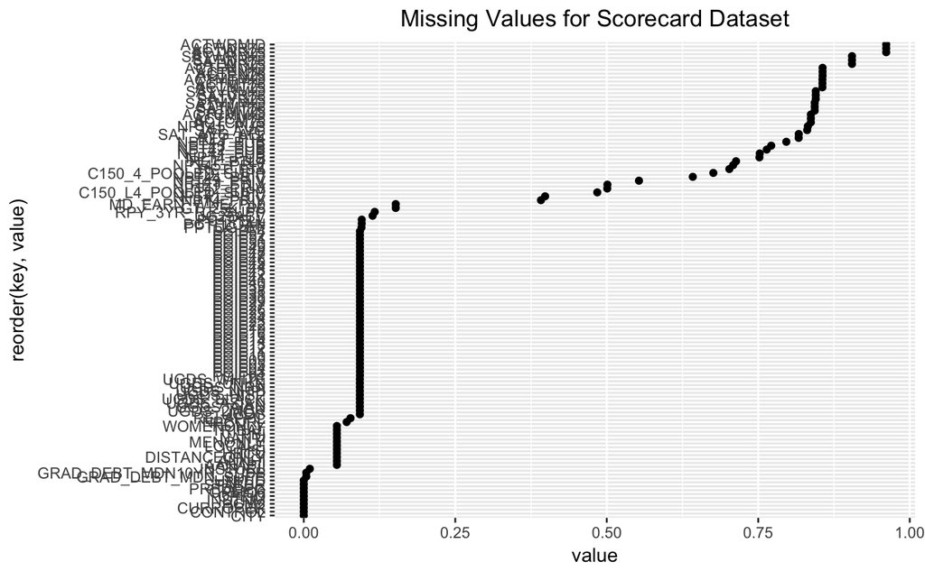

```r
library(tidyr)
Data <- read.csv("Most-Recent-Cohorts-Scorecard-Elements.csv", header = TRUE, sep = ",", na.strings = "NULL")
Data_missing <- gather(data.frame(as.list(sapply(Data, function(x) sum(is.na(x))))))
Data_missing$value <- Data_missing$value / nrow(Data)
ggplot(Data_missing, aes(x=value, y=reorder(key, value))) +
 geom_point() +
 scale_y_discrete(breaks=Data_missing$key, labels = Data_missing$key) +
 theme(legend.title = element_blank()) +
 theme(legend.text.align = 0) +
 theme(plot.title=element_text(hjust = 0.5)) +
 ggtitle('Missing Values for Scorecard Dataset')
```

[output not shown]

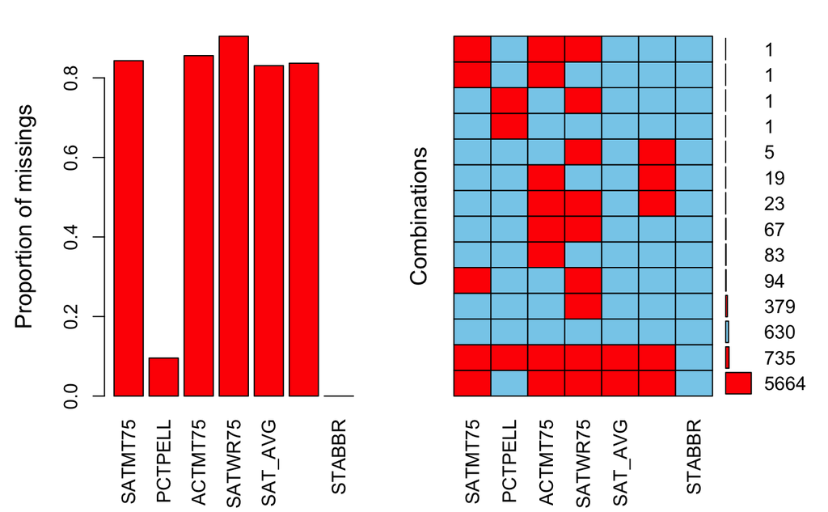

```r
library(VIM)
Data_TBO <- Data[,c("SATMT75","PCTPELL","ACTMT75","SATWR75","SAT_AVG","ACTCMMID","STABBR")]
aggr(Data_TBO, delimiter="_imp", numbers=TRUE, prop=c(TRUE,FALSE))
```

Than using the VIM package we tried to understand the combinations between the features. First, one can see that the distribution of missing data is really different between: STATE, PELL STUDENTS and SAT/ACT SCORES. It seems that all the institutions’ states are indicated as well as most of the Pell Students inside those institution. Then we can see that a lot of institutions do not have students score in the top 75% percentile for the SAT and ACT. Finally SAT_AVG gives us the percentage of institutions with students who did not take the SAT yet and ACTCMMID gives us the percentage of institutions with students who did not take the ACT yet.

To understand the combination of those missing values, we can look at graph on the right side above. Blue boxes means that data are available and red boxes means that the data are missing. The number of the right is the number of occurances. What is great from this graph is that one can see that sometimes we have values for the average score on the test but some data are missing. Then we can wonder how is this possible.

```
'delimiter' is given, but no missing-index-Variable is found
```

```
Click in in the left margin to switch to the previous variable or in the right margin to switch to the next variable.
To regain use of the VIM GUI and the R console, click anywhere else in the graphics window.
```

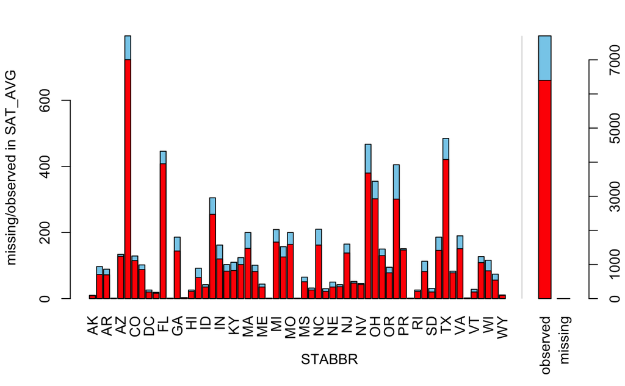

```r
Variable_scorecard <- c("STABBR","SAT_AVG")
histMiss(Data[,Variable_scorecard], delimiter="imp", selection="all", only.miss=FALSE)
```

From this graph, we can notice that some states do have a lot institutions that take the SAT. Then this graph is useful to see how many instituions per state do not have students taking the SAT.